# Spreadsheets, Summaries, and Pivot Tables

Stat 365: Statistical Communication

## Wednesday, April 12th

Today we will…

- Excel Operations
- Persnickety Percentages
- Statistical Terminology – “Average”
- One-number Story

## .xlsx

Download `malaria_data.xlsx`

An article that appeared in the journal Lancet in May of 2021 (Datoo, et al.) described a study that **investigated a potential vaccine that might protect children against malaria**. Researchers recruited children between the ages of 5 and 17 months in Burkina Faso, a country in western Africa, as participants. The **children were randomly assigned into one of three groups: one group received a large dose of the potential vaccine, another group received a small dose, and a third group received a placebo.** Researchers observed the children for the next 18 months, keeping track of **whether or not the child developed malaria.** Researchers hoped, of course, that children who received a vaccine would be less likely to develop malaria than children who received a placebo.

## Excel Operations

- Freeze panes,
- Filter and sort observations,
- Pivot tables, and
- Summaries, etc.

If you think you can do it, Google it!

Excel has a programming language called VBA (Visual Basic Analysis) – most people write macros in this.

## Persnickety Percentages

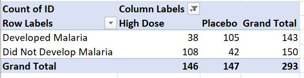

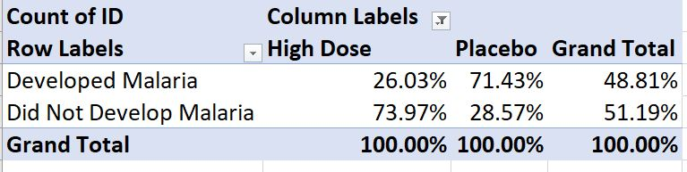

## Interpretting Proportions

- Diff in prop
- Percentage Diff
- Relative Risk
- Odds Ratio

The **difference in success proportions** between two groups, multiplied by 100, should be expressed as a difference in percentage points.

$$p_{success|A} – p_{success|B}$$

The **percentage difference** in success proportions between two groups, with group B as the baseline, is calculated as:
$$\frac{(p_{success|A} – p_{success|B})}{p_{success|B}} × 100%.$$

or equivalently: $\text{percentage difference} = (\text{relative risk} - 1) \times 100$

The **relative risk** between two groups is the ratio of their success proportions.

$$\frac{p_{success|A}}{p_{success|B}}$$

The **odds of success** are calculated as:
$$\frac{\text{# of successes}}{\text{# of failures}}.$$

The **odds against** an event are calculated as
$$\frac{\text{# of failures}}{\text{# of successes}}.$$

Odds ratio is *invariant* to which outcome is labeled a “success”.

## Statistical Terminology - “Average”

### Means, Medians, and Modes

- What does the term “average mean in everyday language?
- When might it be appropriate to use one of the measures for center over the others?

# [Mini Project: One-number Story](https://earobinson95.github.io/stat365-calpoly/97-mini-projects/one-number-story/one-number-story.html)

## To do

**Formal Protocol**

- Due Thursday, 4/13 at 11:59pm

**Peer Review of Formal Protocol**

- Opens on Canvas Friday, 4/14 at 8am
- Due Tuesday, 4/18 at 11:59pm

As soon as you get feedback from your peer, go ahead and start collecting data!

**Ask** if you have any questions.

**One-number Story**

- Draft: due Thursday, 4/20 at 11:59pm
- Peer Review: due Sunday, 4/23 at 11:59pm
- Final submission: due Thursday, 4/27 at 11:59pm

**Read CwD ch. 3.1 - 3.3**